# Chapter 6 Empirical Examples

Xianwen He

2022-07-12

## Reisenzein’s example (1986)

This section aims to reproduce to empirical examples in Chapter 6, Section 6.7. Please install `MIIVsem` and `lavaan` using `install.packages('<package.name>')` if you haven’t done so.

Load the packages.

```r
library(MIIVsem)
library(lavaan)
```

Read in the data.

```r
reisenzein1986 <- readRDS("reisenzein1986a.RDS")
colnames(reisenzein1986) <- c(
"Z1", "Z2", "Z3", "Z4", "Z5", "Z6",
"Z7", "Z8", "Z9", "Z10", "Z11", "Z12",
"Z13"
)
```

### The original model ($M_1$)

Specify the original model ($M_1$).

```r
m1.reisenzein <- '
L1 =~ Z1 + Z2 + Z3
L2 =~ Z4 + Z5 + Z6
L3 =~ Z7 + Z8 + Z9
L4 =~ Z10 + Z11 + Z12
L4 ~ L2 + L3
L2 ~ L1
L3 ~ L1
L1 ~ Z13
'
```

ML fit measures using `lavaan`.

```r
fitmeasures(sem(m1.reisenzein, data = reisenzein1986))
```

```
##                npar                fmin               chisq                  df
##              29.000               0.316              87.213              61.000
##              pvalue      baseline.chisq         baseline.df     baseline.pvalue
##               0.015            1474.631              78.000               0.000
##                 cfi                 tli                nnfi                 rfi
##               0.981               0.976               0.976               0.924
##                 nfi                pnfi                 ifi                 rni
##               0.941               0.736               0.981               0.981
##                logl   unrestricted.logl                 aic                 bic
##           -3050.544           -3006.938            6159.088            6243.978
##              ntotal                bic2               rmsea      rmsea.ci.lower
##             138.000            6152.232               0.056               0.025
##      rmsea.ci.upper        rmsea.pvalue                 rmr          rmr_nomean
##               0.081               0.341               0.225               0.225
##                srmr        srmr_bentler srmr_bentler_nomean                crmr
##               0.047               0.047               0.047               0.050
##         crmr_nomean          srmr_mplus   srmr_mplus_nomean               cn_05
##               0.050               0.047               0.047             127.954
##               cn_01                 gfi                agfi                pgfi
##             142.763               0.931               0.896               0.624
##                 mfi                ecvi
##               0.909               1.052
```

2SLS estimates using `MIIVsem`.

```r
miive(m1.reisenzein, reisenzein1986, sarg.adjust= "holm")
```

```
## MIIVsem (0.5.8) results
##
## Number of observations                                                    138
## Number of equations                                                        12
## Estimator                                                           MIIV-2SLS
## Standard Errors                                                      standard
## Missing                                                              listwise
##
##
## Parameter Estimates:
##
##
## STRUCTURAL COEFFICIENTS:
##                    Estimate  Std.Err  z-value  P(>|z|)   Sargan   df   P(Chi)
##   L1 =~
##     Z1                1.000
##     Z2                1.047    0.080   13.041    0.000   12.085   10    1.000
##     Z3                1.152    0.087   13.218    0.000   11.550   10    1.000
##   L2 =~
##     Z4                1.000
##     Z5                0.724    0.068   10.594    0.000   10.419   10    1.000
##     Z6                0.721    0.061   11.779    0.000   26.677   10    0.032
##   L3 =~
##     Z7                1.000
##     Z8                0.895    0.075   12.009    0.000    5.281   10    1.000
##     Z9                0.885    0.071   12.474    0.000    9.269   10    1.000
##   L4 =~
##     Z10               1.000
##     Z11               1.098    0.059   18.746    0.000    7.632   10    1.000
##     Z12               0.428    0.034   12.686    0.000   11.850   10    1.000
##
##   L1 ~
##     Z13               3.828    0.315   12.142    0.000
##   L2 ~
##     L1               -0.716    0.092   -7.780    0.000   10.436    5    0.510
##   L3 ~
##     L1                0.640    0.078    8.245    0.000   14.644    5    0.120
##   L4 ~
##     L2                0.430    0.082    5.270    0.000   16.016    6    0.123
##     L3               -0.405    0.094   -4.320    0.000
##
## INTERCEPTS:
##                    Estimate  Std.Err  z-value  P(>|z|)
##     L1               -0.978    0.490   -1.998    0.046
##     L2                9.564    0.472   20.266    0.000
##     L3               -0.189    0.398   -0.475    0.635
##     L4                4.730    0.701    6.752    0.000
##     Z1                0.000
##     Z10               0.000
##     Z11              -0.973    0.384   -2.533    0.011
##     Z12               0.697    0.222    3.140    0.002
##     Z2                0.363    0.410    0.884    0.376
##     Z3               -0.948    0.448   -2.117    0.034
##     Z4                0.000
##     Z5                1.868    0.450    4.155    0.000
##     Z6                1.949    0.404    4.829    0.000
##     Z7                0.000
##     Z8                0.864    0.251    3.440    0.001
##     Z9                0.683    0.238    2.871    0.004
```

### $M_2$

Specify the model. Compared to $M_1$, there is an direct impact from $Z_{13}$(‘Stimulus’) to $L_4$(‘Help’), and there are tow pairs of empirically determined correlated errors ($Z_3$ & $Z_4$, $Z_4$ & $Z_{12}$).

```r
m2.reisenzein <- '
  L1 =~ Z1 + Z2 + Z3
  L2 =~ Z4 + Z5 + Z6
  L3 =~ Z7 + Z8 + Z9
  L4 =~ Z10 + Z11 + Z12

  L4 ~ L2 + L3 + Z13
  L2 ~ L1
  L3 ~ L1
  L1 ~ Z13

  Z3 ~~ Z4
  Z4 ~~ Z12
'
```

ML fit measures for $M_2$.

```r
fitmeasures(sem(m2.reisenzein, data = reisenzein1986))
```

```
##                npar                fmin               chisq                  df
##              32.000               0.246              67.776              58.000
##              pvalue      baseline.chisq         baseline.df     baseline.pvalue
##               0.178            1474.631              78.000               0.000
##                 cfi                 tli                nnfi                 rfi
##               0.993               0.991               0.991               0.938
##                 nfi                pnfi                 ifi                 rni
##               0.954               0.709               0.993               0.993
##                logl   unrestricted.logl                 aic                 bic
##           -3040.826           -3006.938            6145.651            6239.323
##              ntotal                bic2               rmsea      rmsea.ci.lower
##             138.000            6138.086               0.035               0.000
##      rmsea.ci.upper        rmsea.pvalue                 rmr          rmr_nomean
##               0.066               0.760               0.213               0.213
##                srmr        srmr_bentler srmr_bentler_nomean                crmr
##               0.041               0.041               0.041               0.045
##         crmr_nomean          srmr_mplus   srmr_mplus_nomean               cn_05
##               0.045               0.042               0.042             157.328
##               cn_01                 gfi                agfi                pgfi
##             176.004               0.946               0.916               0.603
##                 mfi                ecvi
##               0.965               0.955
```

### The cross-loading model ($M_3$)

Specify the model. Add a direct path from $L_4$(‘Help’) to $Z_6$ (‘Concern’).

```r
m3.reisenzein <- '
L1 =~ Z1 + Z2 + Z3
L2 =~ Z4 + Z5 + Z6
L3 =~ Z7 + Z8 + Z9
L4 =~ Z10 + Z11 + Z12 + Z6
L4 ~ L2 + L3
L2 ~ L1
L3 ~ L1
L1 ~ Z13
'
```

ML fit measures.

```r
fitmeasures(sem(m3.reisenzein, data = reisenzein1986))
```

```
##                npar                fmin               chisq                  df
##              30.000               0.244              67.244              60.000
##              pvalue      baseline.chisq         baseline.df     baseline.pvalue
##               0.243            1474.631              78.000               0.000
##                 cfi                 tli                nnfi                 rfi
##               0.995               0.993               0.993               0.941
##                 nfi                pnfi                 ifi                 rni
##               0.954               0.734               0.995               0.995
##                logl   unrestricted.logl                 aic                 bic
##           -3040.559           -3006.938            6141.119            6228.937
##              ntotal                bic2               rmsea      rmsea.ci.lower
##             138.000            6134.027               0.030               0.000
##      rmsea.ci.upper        rmsea.pvalue                 rmr          rmr_nomean
##               0.062               0.827               0.199               0.199
##                srmr        srmr_bentler srmr_bentler_nomean                crmr
##               0.042               0.042               0.042               0.045
##         crmr_nomean          srmr_mplus   srmr_mplus_nomean               cn_05
##               0.045               0.042               0.042             163.294
##               cn_01                 gfi                agfi                pgfi
##             182.375               0.947               0.919               0.624
##                 mfi                ecvi
##               0.974               0.922
```

2SLS estimates for $M_3$.

```r
miive(m3.reisenzein, reisenzein1986, sarg.adjust= "holm")
```

```
## MIIVsem (0.5.8) results
##
## Number of observations                                                    138
## Number of equations                                                        12
## Estimator                                                           MIIV-2SLS
## Standard Errors                                                      standard
## Missing                                                              listwise
##
##
## Parameter Estimates:
##
##
## STRUCTURAL COEFFICIENTS:
##                    Estimate  Std.Err  z-value  P(>|z|)   Sargan   df   P(Chi)
##   L1 =~
##     Z1                1.000
##     Z2                1.047    0.080   13.041    0.000   12.085   10    1.000
##     Z3                1.152    0.087   13.218    0.000   11.550   10    1.000
##   L2 =~
##     Z4                1.000
##     Z5                0.724    0.068   10.594    0.000   10.419   10    1.000
##     Z6                0.473    0.073    6.501    0.000    6.209    8    1.000
##   L3 =~
##     Z7                1.000
##     Z8                0.895    0.075   12.009    0.000    5.281   10    1.000
##     Z9                0.885    0.071   12.474    0.000    9.269   10    1.000
##   L4 =~
##     Z10               1.000
##     Z6                0.388    0.079    4.906    0.000    6.209    8    1.000
##     Z11               1.098    0.059   18.746    0.000    7.632   10    1.000
##     Z12               0.428    0.034   12.686    0.000   11.850   10    1.000
##
##   L1 ~
##     Z13               3.828    0.315   12.142    0.000
##   L2 ~
##     L1               -0.716    0.092   -7.780    0.000   10.436    5    0.638
##   L3 ~
##     L1                0.651    0.078    8.329    0.000   11.951    4    0.195
##   L4 ~
##     L2                0.352    0.086    4.074    0.000    9.424    5    0.840
##     L3               -0.440    0.094   -4.688    0.000
##
## INTERCEPTS:
##                    Estimate  Std.Err  z-value  P(>|z|)
##     L1               -0.978    0.490   -1.998    0.046
##     L2                9.564    0.472   20.266    0.000
##     L3               -0.238    0.400   -0.594    0.553
##     L4                5.318    0.730    7.286    0.000
##     Z1                0.000
##     Z10               0.000
##     Z11              -0.973    0.384   -2.533    0.011
##     Z12               0.697    0.222    3.140    0.002
##     Z2                0.363    0.410    0.884    0.376
##     Z3               -0.948    0.448   -2.117    0.034
##     Z4                0.000
##     Z5                1.868    0.450    4.155    0.000
##     Z6                1.054    0.400    2.634    0.008
##     Z7                0.000
##     Z8                0.864    0.251    3.440    0.001
##     Z9                0.683    0.238    2.871    0.004
```

## Higher-order factor analysis

This section aims to reproduce the empirical examples in Chapter 6, Section 6.8.1.

Read in the data from the study by Colom et al. (2004).

```r
colom.n <- 198
lower.corr <- '
1
0.21    1
0.24    0.11    1
0.34    0.14    0.07    1
0.42    0.12    0.09    0.40    1
0.41    0.19    0.16    0.50  0.49  1
0.19    0.19    0.17    0.18    0.20  0.26  1
0.19    0.22    0.09    0.13    0.04    0.22    0.43    1
0.32    0.17    0.04    0.06    0.16    0.29    0.21    0.39    1
0.30  0.14  0.26    0.20  0.13  0.26    0.28    0.20  0.25  1
0.35    0.23    0.30  0.19  0.06    0.21    0.20  0.32  0.35    0.39    1
0.32    0.29    0.12    0.10  0.17  0.24    0.18    0.42    0.33    0.30  0.49  1
'
mean <- '26.3  30.1  8.9  39.6  37.8  38.3  35  35.2  22.9  15.7  22.4  23.9'
std <- '10.3  9.6  8.6  10.9  9.6  10.5  6.9  6.7  6.5  3.4  10.6  4.6'
labels <- c('z1', 'z2', 'z3', 'z5', 'z6', 'z4',
            'z8', 'z7', 'z9', 'z11', 'z10', 'z12')

colom.corr <- getCov(lower.corr, names=labels)
colom.mean <- as.numeric(strsplit(mean, '  ')[[1]]); names(colom.mean) <- labels
colom.std <- as.numeric(strsplit(std, '  ')[[1]]); names(colom.std) <- labels

# sigma_i * sigma_j * rho_ij = Cov(X_i, X_j)
colom.cov <- (colom.std %*% t(colom.std)) * colom.corr
dimnames(colom.cov) <- list(labels,labels)
```

Define the model.

```r
colom.mod <- '
L1 =~ L2 + L3 + L4 + L5
# measurements
L2 =~ z1 + z2 + z3
L3 =~ z4 + z5 + z6
L4 =~ z7 + z8 + z9
L5 =~ z10 + z11 + z12
'
```

ML estimates by `lavaan`.

```r
colom.fit <- sem(colom.mod,
    sample.cov = colom.cov, sample.mean = colom.mean,
    sample.nobs = colom.n)
# test statistics
fitmeasures(colom.fit)
```

```
##                npar                fmin               chisq                  df
##              40.000               0.262             103.598              50.000
##              pvalue      baseline.chisq         baseline.df     baseline.pvalue
##               0.000             555.674              66.000               0.000
##                 cfi                 tli                nnfi                 rfi
##               0.891               0.856               0.856               0.754
##                 nfi                pnfi                 ifi                 rni
##               0.814               0.616               0.894               0.891
##                logl   unrestricted.logl                 aic                 bic
##           -8002.955           -7951.156           16085.909           16217.440
##              ntotal                bic2               rmsea      rmsea.ci.lower
##             198.000           16090.720               0.074               0.053
##      rmsea.ci.upper        rmsea.pvalue                 rmr          rmr_nomean
##               0.094               0.029               4.360               4.683
##                srmr        srmr_bentler srmr_bentler_nomean                crmr
##               0.059               0.059               0.064               0.064
##         crmr_nomean          srmr_mplus   srmr_mplus_nomean               cn_05
##               0.069               0.059               0.064             130.018
##               cn_01                 gfi                agfi                pgfi
##             146.548               0.993               0.988               0.552
##                 mfi                ecvi
##               0.873               0.927
```

```r
# estimates
summary(colom.fit, standardized = TRUE)
```

```
## lavaan 0.6-11 ended normally after 135 iterations
##
##   Estimator                                         ML
##   Optimization method                           NLMINB
##   Number of model parameters                        40
##
##   Number of observations                           198
##
## Model Test User Model:
##
##   Test statistic                               103.598
##   Degrees of freedom                                50
##   P-value (Chi-square)                           0.000
##
## Parameter Estimates:
##
##   Standard errors                             Standard
##   Information                                 Expected
##   Information saturated (h1) model          Structured
##
## Latent Variables:
##                    Estimate  Std.Err  z-value  P(>|z|)   Std.lv  Std.all
##   L1 =~
##     L2                1.000                               1.039    1.039
##     L3                0.804    0.150    5.373    0.000    0.612    0.612
##     L4                0.515    0.096    5.374    0.000    0.731    0.731
##     L5                0.980    0.169    5.813    0.000    0.847    0.847
##   L2 =~
##     z1                1.000                               6.270    0.610
##     z2                0.588    0.134    4.387    0.000    3.684    0.385
##     z3                0.452    0.118    3.842    0.000    2.837    0.331
##   L3 =~
##     z4                1.000                               8.562    0.818
##     z5                0.784    0.114    6.882    0.000    6.709    0.617
##     z6                0.678    0.100    6.809    0.000    5.808    0.606
##   L4 =~
##     z7                1.000                               4.593    0.687
##     z8                0.807    0.149    5.429    0.000    3.705    0.538
##     z9                0.800    0.143    5.596    0.000    3.673    0.566
##   L5 =~
```

[output cut: 28 more lines]

```
##    .z3               65.538    6.897    9.502    0.000   65.538    0.891
##    .z4               36.382    9.067    4.013    0.000   36.382    0.332
##    .z5               73.205    9.225    7.935    0.000   73.205    0.619
##    .z6               57.966    7.190    8.062    0.000   57.966    0.632
##    .z7               23.567    3.937    5.987    0.000   23.567    0.528
##    .z8               33.643    4.119    8.168    0.000   33.643    0.710
##    .z9               28.548    3.627    7.871    0.000   28.548    0.679
##    .z10              55.028    8.572    6.420    0.000   55.028    0.492
##    .z11               8.203    0.952    8.620    0.000    8.203    0.713
##    .z12              11.954    1.624    7.360    0.000   11.954    0.568
##     L1               42.424   10.465    4.054    0.000    1.000    1.000
##    .L2               -3.111    8.182   -0.380    0.704   -0.079   -0.079
##    .L3               45.881   10.515    4.363    0.000    0.626    0.626
##    .L4                9.826    3.389    2.899    0.004    0.466    0.466
##    .L5               16.055    7.380    2.175    0.030    0.283    0.283
```

Specify two MIIVs for each observed variable and applies `MIIVsem` for 2SLS estimates. The script for MIIV selection can be found in the folder supplement.

```r
colom.miiv <- '
z4 ~ z9 + z10
z7 ~ z6 + z10
z10 ~ z6 + z9
z2 ~ z3 + z6
z3 ~ z2 + z6
z5 ~ z6 + z1
z6 ~ z5 + z9
z8 ~ z9 + z12
z9 ~ z8 + z12
z11 ~ z12 + z3
z12 ~ z11 + z9
'

miive(model = colom.mod, instruments = colom.miiv,
      sample.cov = colom.cov, sample.mean = colom.mean,
      sample.nobs = colom.n)
```

```
## MIIVsem (0.5.8) results
##
## Number of observations                                                    198
## Number of equations                                                        11
## Estimator                                                           MIIV-2SLS
## Standard Errors                                                      standard
## Missing                                                              listwise
##
##
## Parameter Estimates:
##
##
## STRUCTURAL COEFFICIENTS:
##                    Estimate  Std.Err  z-value  P(>|z|)   Sargan   df   P(Chi)
##   L1 =~
##     L2                1.000
##     L3                0.746    0.172    4.352    0.000    1.699    1    0.192
##     L4                0.277    0.088    3.156    0.002   10.007    1    0.002
##     L5                0.483    0.140    3.439    0.001   15.381    1    0.000
##   L2 =~
##     z1                1.000
##     z2                0.302    0.140    2.164    0.030    0.287    1    0.592
##     z3                0.222    0.128    1.735    0.083    0.785    1    0.376
##   L3 =~
##     z4                1.000
##     z5                0.852    0.126    6.743    0.000    0.007    1    0.935
##     z6                0.677    0.105    6.479    0.000    0.985    1    0.321
##   L4 =~
##     z7                1.000
##     z8                0.492    0.133    3.696    0.000    0.356    1    0.551
##     z9                0.614    0.119    5.174    0.000    2.125    1    0.145
##   L5 =~
##     z10               1.000
##     z11               0.216    0.040    5.387    0.000    1.011    1    0.315
##     z12               0.366    0.062    5.920    0.000    0.609    1    0.435
##
## INTERCEPTS:
##                    Estimate  Std.Err  z-value  P(>|z|)
##     L2                0.000
##     L3               18.671    4.568    4.088    0.000
##     L4               27.907    2.360   11.825    0.000
##     L5                9.704    3.760    2.581    0.010
##     z1                0.000
##     z10               0.000
##     z11              10.852    0.929   11.678    0.000
##     z12              15.700    1.419   11.066    0.000
##     z2               22.145    3.737    5.927    0.000
##     z3                3.052    3.422    0.892    0.372
##     z4                0.000
##     z5                6.964    4.892    1.423    0.155
##     z6               11.856    4.051    2.926    0.003
##     z7                0.000
##     z8               17.692    4.704    3.761    0.000
##     z9                1.291    4.199    0.307    0.759
```

## Longitudinal model

This section aims to reproduce the empirical examples in Chapter 6, Section 6.8.2.

Read in the NLSY data.

```r
dat.long <- read.table('./halaby2.dat', header=TRUE, sep=" ", dec=",")
```

### Fixed Effects Model ($M_1$)

Fit a FEM without lagged effects.

```r
# FEM without lagged effects
m1.fem<-'
#measurement model
alpha=~1*lnwg80+1*lnwg81+1*lnwg82+1*lnwg83+1*lnwg84+1*lnwg85+1*lnwg86+1*lnwg87
lnwg80~1
lnwg81~1
lnwg82~1
lnwg83~1
lnwg84~1
lnwg85~1
lnwg86~1
lnwg87~1
#lnwg80~~v*lnwg80
#lnwg81~~v*lnwg81
#lnwg82~~v*lnwg82
#lnwg83~~v*lnwg83
#lnwg84~~v*lnwg84
#lnwg85~~v*lnwg85
#lnwg86~~v*lnwg86
#lnwg87~~v*lnwg87
#structural model
lnwg80~a1*SEI.10_80+a2*union80
lnwg81~a1*SEI.10_81+a2*union81
lnwg82~a1*SEI.10_82+a2*union82
lnwg83~a1*SEI.10_83+a2*union83
lnwg84~a1*SEI.10_84+a2*union84
lnwg85~a1*SEI.10_85+a2*union85
lnwg86~a1*SEI.10_86+a2*union86
lnwg87~a1*SEI.10_87+a2*union87

alpha~0
alpha~~SEI.10_80+SEI.10_81+SEI.10_82+SEI.10_83+SEI.10_84+SEI.10_85+SEI.10_86+SEI.10_87+union80+union81+union82+union83+union84+union85+union86+union87
SEI.10_80~~SEI.10_81+SEI.10_82+SEI.10_83+SEI.10_84+SEI.10_85+SEI.10_86+SEI.10_87+union80+union81+union82+union83+union84+union85+union86+union87
SEI.10_81~~SEI.10_82+SEI.10_83+SEI.10_84+SEI.10_85+SEI.10_86+SEI.10_87+union80+union81+union82+union83+union84+union85+union86+union87
SEI.10_82~~SEI.10_83+SEI.10_84+SEI.10_85+SEI.10_86+SEI.10_87+union80+union81+union82+union83+union84+union85+union86+union87
SEI.10_83~~SEI.10_84+SEI.10_85+SEI.10_86+SEI.10_87+union80+union81+union82+union83+union84+union85+union86+union87
SEI.10_84~~SEI.10_85+SEI.10_86+SEI.10_87+union80+union81+union82+union83+union84+union85+union86+union87
SEI.10_85~~SEI.10_86+SEI.10_87+union80+union81+union82+union83+union84+union85+union86+union87
SEI.10_86~~SEI.10_87+union80+union81+union82+union83+union84+union85+union86+union87
SEI.10_87~~union80+union81+union82+union83+union84+union85+union86+union87
union80~~union81+union82+union83+union84+union85+union86+union87
union81~~union82+union83+union84+union85+union86+union87
union82~~union83+union84+union85+union86+union87
union83~~union84+union85+union86+union87
union84~~union85+union86+union87
union85~~union86+union87
union86~~union87'

fit.1.fem <- sem(m1.fem, data=dat.long, fixed.x=FALSE)
# summary(fit.1.fem, fit.measure=TRUE)
fitmeasures(fit.1.fem)
```

```
##                npar                fmin               chisq                  df
##             187.000               0.376             409.997             137.000
##              pvalue      baseline.chisq         baseline.df     baseline.pvalue
##               0.000            6439.468             276.000               0.000
##                 cfi                 tli                nnfi                 rfi
##               0.956               0.911               0.911               0.872
##                 nfi                pnfi                 ifi                 rni
##               0.936               0.465               0.957               0.956
##                logl   unrestricted.logl                 aic                 bic
##           -7051.597           -6846.599           14477.195           15281.442
##              ntotal                bic2               rmsea      rmsea.ci.lower
##             545.000           14687.831               0.060               0.054
##      rmsea.ci.upper        rmsea.pvalue                 rmr          rmr_nomean
##               0.067               0.005               0.011               0.011
##                srmr        srmr_bentler srmr_bentler_nomean                crmr
##               0.040               0.040               0.042               0.040
##         crmr_nomean          srmr_mplus   srmr_mplus_nomean               cn_05
##               0.034               0.042               0.037             220.751
##               cn_01                 gfi                agfi                pgfi
##             238.171               0.979               0.949               0.414
##                 mfi                ecvi
##               0.778               1.439
```

### Random Effects Model ($M_2$)

Fit a REM without lagged effects.

```r
m2.rem<-'
#measurement model
alpha=~1*lnwg80+1*lnwg81+1*lnwg82+1*lnwg83+1*lnwg84+1*lnwg85+1*lnwg86+1*lnwg87
lnwg80~1
lnwg81~1
lnwg82~1
lnwg83~1
lnwg84~1
lnwg85~1
lnwg86~1
lnwg87~1
#lnwg80~~v*lnwg80
#lnwg81~~v*lnwg81
#lnwg82~~v*lnwg82
#lnwg83~~v*lnwg83
#lnwg84~~v*lnwg84
#lnwg85~~v*lnwg85
#lnwg86~~v*lnwg86
#lnwg87~~v*lnwg87
#structural model
lnwg80~a1*SEI.10_80+a2*union80+a3*educ+a4*black
lnwg81~a1*SEI.10_81+a2*union81+a3*educ+a4*black
lnwg82~a1*SEI.10_82+a2*union82+a3*educ+a4*black
lnwg83~a1*SEI.10_83+a2*union83+a3*educ+a4*black
lnwg84~a1*SEI.10_84+a2*union84+a3*educ+a4*black
lnwg85~a1*SEI.10_85+a2*union85+a3*educ+a4*black
lnwg86~a1*SEI.10_86+a2*union86+a3*educ+a4*black
lnwg87~a1*SEI.10_87+a2*union87+a3*educ+a4*black

alpha~0
'

fit.2.rem<-sem(m2.rem, data=dat.long, fixed.x=FALSE)
# summary(fit.2.rem, fit.measure=TRUE)
fitmeasures(fit.2.rem)
```

```
##                npar                fmin               chisq                  df
##             210.000               0.427             465.963             167.000
##              pvalue      baseline.chisq         baseline.df     baseline.pvalue
##               0.000            2746.741             172.000               0.000
##                 cfi                 tli                nnfi                 rfi
##               0.884               0.880               0.880               0.825
##                 nfi                pnfi                 ifi                 rni
##               0.830               0.806               0.884               0.884
##                logl   unrestricted.logl                 aic                 bic
##           -8227.287           -7994.306           16874.574           17777.739
##              ntotal                bic2               rmsea      rmsea.ci.lower
##             545.000           17111.117               0.057               0.051
##      rmsea.ci.upper        rmsea.pvalue                 rmr          rmr_nomean
##               0.064               0.025               0.016               0.017
##                srmr        srmr_bentler srmr_bentler_nomean                crmr
##               0.057               0.057               0.059               0.058
##         crmr_nomean          srmr_mplus   srmr_mplus_nomean               cn_05
##               0.056               0.058               0.056             232.765
##               cn_01                 gfi                agfi                pgfi
##             249.464               0.989               0.974               0.438
##                 mfi                ecvi
##               0.760               1.626
```

### Latent Growth Curve Model ($M_3$)

Fit a linear growth model.

```r
m3.gr_lin<-'
#measurement model
alpha=~1*lnwg80+1*lnwg81+1*lnwg82+1*lnwg83+1*lnwg84+1*lnwg85+1*lnwg86+1*lnwg87
beta=~0*lnwg80+1*lnwg81+2*lnwg82+3*lnwg83+4*lnwg84+5*lnwg85+6*lnwg86+7*lnwg87

lnwg80~0
lnwg81~0
lnwg82~0
lnwg83~0
lnwg84~0
lnwg85~0
lnwg86~0
lnwg87~0
lnwg80~~lnwg80
lnwg81~~lnwg81
lnwg82~~lnwg82
lnwg83~~lnwg83
lnwg84~~lnwg84
lnwg85~~lnwg85
lnwg86~~lnwg86
lnwg87~~lnwg87
#structural model
lnwg80~a1*SEI.10_80+a2*union80
lnwg81~a1*SEI.10_81+a2*union81
lnwg82~a1*SEI.10_82+a2*union82
lnwg83~a1*SEI.10_83+a2*union83
lnwg84~a1*SEI.10_84+a2*union84
lnwg85~a1*SEI.10_85+a2*union85
lnwg86~a1*SEI.10_86+a2*union86
lnwg87~a1*SEI.10_87+a2*union87

alpha~1
beta~1
alpha~educ+black
beta~educ+black
alpha~~beta'

fit.3.gr_lin<-sem(m3.gr_lin, data=dat.long)
# summary(fit.3.gr_lin, fit.measure=TRUE)
fitmeasures(fit.3.gr_lin)
```

```
##                npar                fmin               chisq                  df
##              19.000               0.296             322.211             169.000
##              pvalue      baseline.chisq         baseline.df     baseline.pvalue
##               0.000            2746.741             172.000               0.000
##                 cfi                 tli                nnfi                 rfi
##               0.940               0.939               0.939               0.881
##                 nfi                pnfi                 ifi                 rni
##               0.883               0.867               0.941               0.940
##                logl   unrestricted.logl                 aic                 bic
##           -2044.441           -1883.335            4126.881            4208.596
##              ntotal                bic2               rmsea      rmsea.ci.lower
##             545.000            4148.283               0.041               0.034
##      rmsea.ci.upper        rmsea.pvalue                 rmr          rmr_nomean
##               0.048               0.989               0.015               0.015
##                srmr        srmr_bentler srmr_bentler_nomean                crmr
##               0.054               0.054               0.056               0.055
##         crmr_nomean          srmr_mplus   srmr_mplus_nomean               cn_05
##               0.053               0.055               0.054             339.852
##               cn_01                 gfi                agfi                pgfi
##             364.127               0.978               0.952               0.439
##                 mfi                ecvi
##               0.869               0.661
```

### Autoregressive Model ($M_4$)

Fit a straight auto-regressive model.

```r
m4.ar<-'
#measurement model
lnwg80~1
lnwg81~1
lnwg82~1
lnwg83~1
lnwg84~1
lnwg85~1
lnwg86~1
lnwg87~1
lnwg80~~lnwg80
lnwg81~~lnwg81
lnwg82~~lnwg82
lnwg83~~lnwg83
lnwg84~~lnwg84
lnwg85~~lnwg85
lnwg86~~lnwg86
lnwg87~~lnwg87
#structural model
lnwg80~SEI.10_80+union80+a3*educ+a4*black
lnwg81~rho*lnwg80+a1*SEI.10_81+a2*union81+a3*educ+a4*black
lnwg82~rho*lnwg81+a1*SEI.10_82+a2*union82+a3*educ+a4*black
lnwg83~rho*lnwg82+a1*SEI.10_83+a2*union83+a3*educ+a4*black
lnwg84~rho*lnwg83+a1*SEI.10_84+a2*union84+a3*educ+a4*black
lnwg85~rho*lnwg84+a1*SEI.10_85+a2*union85+a3*educ+a4*black
lnwg86~rho*lnwg85+a1*SEI.10_86+a2*union86+a3*educ+a4*black
lnwg87~rho*lnwg86+a1*SEI.10_87+a2*union87+a3*educ+a4*black
'

fit.4.ar<-sem(m4.ar,data=dat.long)
# summary(fit.4.ar, fit.measure=TRUE)
fitmeasures(fit.4.ar)
```

```
##                npar                fmin               chisq                  df
##              23.000               0.545             594.011             165.000
##              pvalue      baseline.chisq         baseline.df     baseline.pvalue
##               0.000            2746.741             172.000               0.000
##                 cfi                 tli                nnfi                 rfi
##               0.833               0.826               0.826               0.775
##                 nfi                pnfi                 ifi                 rni
##               0.784               0.752               0.834               0.833
##                logl   unrestricted.logl                 aic                 bic
##           -2180.341           -1883.335            4406.681            4505.599
##              ntotal                bic2               rmsea      rmsea.ci.lower
##             545.000            4432.588               0.069               0.063
##      rmsea.ci.upper        rmsea.pvalue                 rmr          rmr_nomean
##               0.075               0.000               0.019               0.020
##                srmr        srmr_bentler srmr_bentler_nomean                crmr
##               0.072               0.072               0.074               0.075
##         crmr_nomean          srmr_mplus   srmr_mplus_nomean               cn_05
##               0.074               0.073               0.073             180.804
##               cn_01                 gfi                agfi                pgfi
##             193.834               0.976               0.944               0.427
##                 mfi                ecvi
##               0.675               1.174
```

### LV-ALT1 ($M_5$)

```r
m5.lv_lin<-'
#measurement model
eta_1=~lnwg80
eta_2=~lnwg81
eta_3=~lnwg82
eta_4=~lnwg83
eta_5=~lnwg84
eta_6=~lnwg85
eta_7=~lnwg86
eta_8=~lnwg87
alpha=~1*eta_2+1*eta_3+1*eta_4+1*eta_5+1*eta_6+1*eta_7+1*eta_8
beta=~1*eta_2+2*eta_3+3*eta_4+4*eta_5+5*eta_6+6*eta_7+7*eta_8

lnwg80~0
lnwg81~0
lnwg82~0
lnwg83~0
lnwg84~0
lnwg85~0
lnwg86~0
lnwg87~0
lnwg80~~v1*lnwg80
lnwg81~~v1*lnwg81
lnwg82~~lnwg82
lnwg83~~lnwg83
lnwg84~~lnwg84
lnwg85~~lnwg85
lnwg86~~lnwg86
lnwg87~~lnwg87

#structural model
eta_2~rho2*eta_1+a1*SEI.10_81+a2*union81+a3*educ+a4*black
eta_3~rho3*eta_2+a1*SEI.10_82+a2*union82+a3*educ+a4*black
eta_4~rho4*eta_3+a1*SEI.10_83+a2*union83+a3*educ+a4*black
eta_5~rho5*eta_4+a1*SEI.10_84+a2*union84+a3*educ+a4*black
eta_6~rho6*eta_5+a1*SEI.10_85+a2*union85+a3*educ+a4*black
eta_7~rho7*eta_6+a1*SEI.10_86+a2*union86+a3*educ+a4*black
eta_8~rho8*eta_7+a1*SEI.10_87+a2*union87+a3*educ+a4*black

alpha~1
beta~1
eta_1~1
eta_1~~eta_1
eta_2~~v*eta_2
eta_3~~v*eta_3
eta_4~~v*eta_4
eta_5~~v*eta_5
eta_6~~v*eta_6
eta_7~~v*eta_7
eta_8~~v*eta_8
alpha~~0*black+0*educ
beta~~0*black+0*educ
alpha~~eta_1+beta+ SEI.10_81+SEI.10_82+SEI.10_83+SEI.10_84+SEI.10_85+SEI.10_86+SEI.10_87+union81+union82+union83+union84+union85+union86+union87
beta~~eta_1+SEI.10_81+SEI.10_82+SEI.10_83+SEI.10_84+SEI.10_85+SEI.10_86+SEI.10_87+union81+union82+union83+union84+union85+union86+union87
eta_1~~SEI.10_81+SEI.10_82+SEI.10_83+SEI.10_84+SEI.10_85+SEI.10_86+SEI.10_87+union81+union82+union83+union84+union85+union86+union87+educ+black
SEI.10_81~~SEI.10_82+SEI.10_83+SEI.10_84+SEI.10_85+SEI.10_86+SEI.10_87+union81+union82+union83+union84+union85+union86+union87+educ+black
SEI.10_82~~SEI.10_83+SEI.10_84+SEI.10_85+SEI.10_86+SEI.10_87+union81+union82+union83+union84+union85+union86+union87+educ+black
SEI.10_83~~SEI.10_84+SEI.10_85+SEI.10_86+SEI.10_87+union81+union82+union83+union84+union85+union86+union87+educ+black
SEI.10_84~~SEI.10_85+SEI.10_86+SEI.10_87+union81+union82+union83+union84+union85+union86+union87+educ+black
SEI.10_85~~SEI.10_86+SEI.10_87+union81+union82+union83+union84+union85+union86+union87+educ+black
SEI.10_86~~SEI.10_87+union81+union82+union83+union84+union85+union86+union87+educ+black
SEI.10_87~~union81+union82+union83+union84+union85+union86+union87+educ+black
union81~~union82+union83+union84+union85+union86+union87+educ+black
union82~~union83+union84+union85+union86+union87+educ+black
union83~~union84+union85+union86+union87+educ+black
union84~~union85+union86+union87+educ+black
union85~~union86+union87+educ+black
union86~~union87+educ+black
union87~~educ+black
educ~~black
'

fit.5.lv_lin <- sem(m5.lv_lin, data=dat.long, fixed.x=FALSE)
```

ML fit measures.

```r
fitmeasures(fit.5.lv_lin)
```

```
##                npar                fmin               chisq                  df
##             224.000               0.118             128.318             100.000
##              pvalue      baseline.chisq         baseline.df     baseline.pvalue
##               0.030            6174.122             276.000               0.000
##                 cfi                 tli                nnfi                 rfi
##               0.995               0.987               0.987               0.943
##                 nfi                pnfi                 ifi                 rni
##               0.979               0.355               0.995               0.995
##                logl   unrestricted.logl                 aic                 bic
##           -7446.218           -7382.059           15340.436           16303.812
##              ntotal                bic2               rmsea      rmsea.ci.lower
##             545.000           15592.749               0.023               0.008
##      rmsea.ci.upper        rmsea.pvalue                 rmr          rmr_nomean
##               0.034               1.000               0.004               0.004
##                srmr        srmr_bentler srmr_bentler_nomean                crmr
##               0.015               0.015               0.016               0.016
##         crmr_nomean          srmr_mplus   srmr_mplus_nomean               cn_05
##               0.015               0.017               0.015             529.114
##               cn_01                 gfi                agfi                pgfi
##             577.807               0.997               0.990               0.308
##                 mfi                ecvi
##               0.974               1.057
```

ML estimates.

```r
summary(fit.5.lv_lin, fit.measure=FALSE)
```

```
## lavaan 0.6-11 ended normally after 390 iterations
##
##   Estimator                                         ML
##   Optimization method                           NLMINB
##   Number of model parameters                       255
##   Number of equality constraints                    31
##
##   Number of observations                           545
##
## Model Test User Model:
##
##   Test statistic                               128.318
##   Degrees of freedom                               100
##   P-value (Chi-square)                           0.030
##
## Parameter Estimates:
##
##   Standard errors                             Standard
##   Information                                 Expected
##   Information saturated (h1) model          Structured
##
## Latent Variables:
##                    Estimate  Std.Err  z-value  P(>|z|)
##   eta_1 =~
##     lnwg80            1.000
##   eta_2 =~
##     lnwg81            1.000
##   eta_3 =~
##     lnwg82            1.000
##   eta_4 =~
##     lnwg83            1.000
##   eta_5 =~
##     lnwg84            1.000
##   eta_6 =~
##     lnwg85            1.000
##   eta_7 =~
##     lnwg86            1.000
##   eta_8 =~
##     lnwg87            1.000
##   alpha =~
```

[output cut: 364 more lines]

```
##     black             0.102    0.006   16.508    0.000
##     SEI.10_82         0.425    0.026   16.508    0.000
##     union82           0.191    0.012   16.509    0.000
##     SEI.10_83         0.426    0.026   16.508    0.000
##     union83           0.185    0.011   16.510    0.000
##     SEI.10_84         0.461    0.028   16.508    0.000
##     union84           0.188    0.011   16.509    0.000
##     SEI.10_85         0.416    0.025   16.508    0.000
##     union85           0.174    0.011   16.509    0.000
##     SEI.10_86         0.411    0.025   16.508    0.000
##     union86           0.166    0.010   16.509    0.000
##     SEI.10_87         0.467    0.028   16.508    0.000
##     union87           0.194    0.012   16.508    0.000
##     alpha             0.070    0.020    3.524    0.000
##     beta              0.001    0.000    3.736    0.000
```

### LV-ALT2 ($M_6$ )

```r
m6.lv_lin_new<-'
#measurement model
eta_1=~lnwg80
eta_2=~lnwg81
eta_3=~lnwg82
eta_4=~lnwg83
eta_5=~lnwg84
eta_6=~lnwg85
eta_7=~lnwg86
eta_8=~lnwg87
alpha=~1*eta_2+1*eta_3+1*eta_4+1*eta_5+1*eta_6+1*eta_7+1*eta_8
beta=~1*eta_2+2*eta_3+3*eta_4+4*eta_5+5*eta_6+6*eta_7+7*eta_8

lnwg80~0
lnwg81~0
lnwg82~0
lnwg83~0
lnwg84~0
lnwg85~0
lnwg86~0
lnwg87~0
lnwg80~~var*lnwg80
lnwg81~~var*lnwg81
lnwg82~~lnwg82
lnwg83~~lnwg83
lnwg84~~lnwg84
lnwg85~~lnwg85
lnwg86~~lnwg86
lnwg87~~lnwg87
#structural model
eta_2~rho*eta_1+a1*SEI.10_81+a2*union81
eta_3~rho*eta_2+a1*SEI.10_82+a2*union82
eta_4~rho*eta_3+a1*SEI.10_83+a2*union83
eta_5~rho*eta_4+a1*SEI.10_84+a2*union84
eta_6~rho*eta_5+a1*SEI.10_85+a2*union85
eta_7~rho*eta_6+a1*SEI.10_86+a2*union86
eta_8~rho*eta_7+a1*SEI.10_87+a2*union87

alpha~1
beta~1
eta_1~1
alpha~educ+black
beta~educ+black
eta_1~SEI.10_80+union80+educ+black
eta_1~~eta_1
eta_2~~v*eta_2
eta_3~~v*eta_3
eta_4~~v*eta_4
eta_5~~v*eta_5
eta_6~~v*eta_6
eta_7~~v*eta_7
eta_8~~v*eta_8
alpha~~eta_1+beta
beta~~eta_1
'

fit.6.lv_lin_new<-sem(m6.lv_lin_new, data=dat.long, fixed.x=FALSE)
```

ML fit measures.

```r
fitmeasures(fit.6.lv_lin_new)
```

```
##                npar                fmin               chisq                  df
##             217.000               0.198             215.692             160.000
##              pvalue      baseline.chisq         baseline.df     baseline.pvalue
##               0.002            2746.741             172.000               0.000
##                 cfi                 tli                nnfi                 rfi
##               0.978               0.977               0.977               0.916
##                 nfi                pnfi                 ifi                 rni
##               0.921               0.857               0.978               0.978
##                logl   unrestricted.logl                 aic                 bic
##           -8102.152           -7994.306           16638.304           17571.574
##              ntotal                bic2               rmsea      rmsea.ci.lower
##             545.000           16882.731               0.025               0.016
##      rmsea.ci.upper        rmsea.pvalue                 rmr          rmr_nomean
##               0.034               1.000               0.011               0.011
##                srmr        srmr_bentler srmr_bentler_nomean                crmr
##               0.039               0.039               0.040               0.040
##         crmr_nomean          srmr_mplus   srmr_mplus_nomean               cn_05
##               0.040               0.039               0.039             482.388
##               cn_01                 gfi                agfi                pgfi
##             517.797               0.995               0.988               0.422
##                 mfi                ecvi
##               0.950               1.192
```

ML estimates.

```r
summary(fit.6.lv_lin_new, fit.measure=FALSE)
```

```
## lavaan 0.6-11 ended normally after 322 iterations
##
##   Estimator                                         ML
##   Optimization method                           NLMINB
##   Number of model parameters                       242
##   Number of equality constraints                    25
##
##   Number of observations                           545
##
## Model Test User Model:
##
##   Test statistic                               215.692
##   Degrees of freedom                               160
##   P-value (Chi-square)                           0.002
##
## Parameter Estimates:
##
##   Standard errors                             Standard
##   Information                                 Expected
##   Information saturated (h1) model          Structured
##
## Latent Variables:
##                    Estimate  Std.Err  z-value  P(>|z|)
##   eta_1 =~
##     lnwg80            1.000
##   eta_2 =~
##     lnwg81            1.000
##   eta_3 =~
##     lnwg82            1.000
##   eta_4 =~
##     lnwg83            1.000
##   eta_5 =~
##     lnwg84            1.000
##   eta_6 =~
##     lnwg85            1.000
##   eta_7 =~
##     lnwg86            1.000
##   eta_8 =~
##     lnwg87            1.000
##   alpha =~
```

[output cut: 299 more lines]

```
##     union82           0.191    0.012   16.508    0.000
##     SEI.10_8          0.426    0.026   16.508    0.000
##     union83           0.185    0.011   16.508    0.000
##     SEI.10_8          0.461    0.028   16.508    0.000
##     union84           0.188    0.011   16.508    0.000
##     SEI.10_8          0.416    0.025   16.508    0.000
##     union85           0.174    0.011   16.508    0.000
##     SEI.10_8          0.411    0.025   16.508    0.000
##     union86           0.166    0.010   16.508    0.000
##     SEI.10_8          0.467    0.028   16.508    0.000
##     union87           0.194    0.012   16.508    0.000
##     educ              3.048    0.185   16.508    0.000
##     black             0.102    0.006   16.508    0.000
##     SEI.10_8          0.378    0.023   16.508    0.000
##     union80           0.188    0.011   16.508    0.000
```

## Bayes SEM

This section aims to reproduce the empirical examples in Chapter 6, Section 6.9.

Load the package.

```r
library("blavaan")
```

Read in the data.

```r
dat.bollen <- MIIVsem::bollen1989a
# rename the variables.
colnames(dat.bollen) <- c("Z4", "Z5", "Z6",
                          "Z7", "Z8", "Z9",
                          "Z10", "Z11",
                          "Z1", "Z2", "Z3" )
```

Summarize the dataset.

```r
dat.summ <- t(apply(dat.bollen, 2,
                    function(x){
                      return (c(quantile(x), mean(x), sd(x)))
                      }
                    ))
dat.summ <- data.frame(rbind(dat.summ[9:11, ], dat.summ[1:8, ]))
colnames(dat.summ) <- c('Min', '25%', 'Median', '75%', 'Max', 'Mean', 'Sd.')
dat.summ
```

```
##          Min      25%   Median      75%       Max     Mean       Sd.
## Z1  3.784190 4.477337 5.075174 5.515424  6.736967 5.054384 0.7329043
## Z2  1.386294 3.663233 4.962845 5.830362  7.872074 4.792195 1.5106644
## Z3  1.001674 2.300181 3.568079 4.522988  6.424591 3.557690 1.4057112
## Z4  1.250000 2.900000 5.400000 7.500000 10.000000 5.464667 2.6227020
## Z5  0.000000 0.000000 3.333333 8.283332  9.999998 4.256443 3.9471276
## Z6  0.000000 3.766667 6.666666 9.999998 10.000000 6.563110 3.2808912
## Z7  0.000000 1.581500 3.333333 6.666666 10.000000 4.452533 3.3494674
## Z8  0.000000 3.691701 5.000000 7.500000 10.000000 5.136252 2.6126022
## Z9  0.000000 0.000000 2.233333 4.206853  9.999998 2.978074 3.3727326
## Z10 0.000000 3.477661 6.666666 9.999998  9.999998 6.196264 3.2862398
## Z11 0.000000 1.300916 3.333333 6.666666 10.000000 4.043390 3.2455927
```

### Estimation

Specify the model.

```r
mod.indem <- '
  L1 =~ Z1 + Z2 + Z3
  L2 =~ Z4 + Z5 + Z6  + Z7
  L3 =~ Z8 + Z9 + Z10 + Z11

  L2  ~ L1
  L3  ~ L1 + L2

  L1 ~ 1
  Z1 ~ 0
  L2 ~ 1
  Z4 ~ 0
  L3 ~ 1
  Z8 ~ 0

  Z4 ~~ Z8
  Z5 ~~ Z7 + Z9
  Z6 ~~ Z10
  Z7 ~~ Z11
  Z9 ~~ Z11 '
```

MIIV-2SLS estimation with `MIIVsem`.

```r
miive(mod.indem, dat.bollen)
```

```
## MIIVsem (0.5.8) results
##
## Number of observations                                                     75
## Number of equations                                                        10
## Estimator                                                           MIIV-2SLS
## Standard Errors                                                      standard
## Missing                                                              listwise
##
##
## Parameter Estimates:
##
##
## STRUCTURAL COEFFICIENTS:
##                    Estimate  Std.Err  z-value  P(>|z|)   Sargan   df   P(Chi)
##   L1 =~
##     Z1                1.000
##     Z2                2.078    0.128   16.171    0.000    8.301    8    0.405
##     Z3                1.751    0.149   11.782    0.000    8.738    8    0.365
##   L2 =~
##     Z4                1.000
##     Z5                1.139    0.179    6.371    0.000    8.409    5    0.135
##     Z6                0.969    0.140    6.924    0.000    5.874    6    0.437
##     Z7                1.210    0.139    8.713    0.000    4.276    5    0.510
##   L3 =~
##     Z8                1.000
##     Z9                1.051    0.165    6.377    0.000    8.712    5    0.121
##     Z10               1.180    0.151    7.814    0.000    9.538    6    0.146
##     Z11               1.203    0.154    7.798    0.000    2.795    5    0.731
##
##   L2 ~
##     L1                1.261    0.426    2.962    0.003    0.503    1    0.478
##   L3 ~
##     L1                1.123    0.312    3.598    0.000    0.801    3    0.849
##     L2                0.724    0.101    7.140    0.000
##
## INTERCEPTS:
##                    Estimate  Std.Err  z-value  P(>|z|)
##     L2               -0.909    2.170   -0.419    0.675
##     L3               -4.499    1.424   -3.160    0.002
##     Z1                0.000
##     Z10               0.135    0.830    0.163    0.870
##     Z11              -2.137    0.853   -2.505    0.012
##     Z2               -5.711    0.654   -8.727    0.000
##     Z3               -5.292    0.758   -6.985    0.000
##     Z4                0.000
##     Z5               -1.969    1.044   -1.886    0.059
##     Z6                1.265    0.814    1.553    0.120
##     Z7               -2.160    0.814   -2.654    0.008
##     Z8                0.000
##     Z9               -2.418    0.909   -2.659    0.008
```

ML estimation with `lavaan`.

```r
Lavfit <- sem(mod.indem, data = dat.bollen)
summary(Lavfit, standardized = TRUE)
```

```
## lavaan 0.6-11 ended normally after 119 iterations
##
##   Estimator                                         ML
##   Optimization method                           NLMINB
##   Number of model parameters                        42
##
##   Number of observations                            75
##
## Model Test User Model:
##
##   Test statistic                                38.125
##   Degrees of freedom                                35
##   P-value (Chi-square)                           0.329
##
## Parameter Estimates:
##
##   Standard errors                             Standard
##   Information                                 Expected
##   Information saturated (h1) model          Structured
##
## Latent Variables:
##                    Estimate  Std.Err  z-value  P(>|z|)   Std.lv  Std.all
##   L1 =~
##     Z1                1.000                               0.670    0.920
##     Z2                2.180    0.139   15.742    0.000    1.460    0.973
##     Z3                1.819    0.152   11.967    0.000    1.218    0.872
##   L2 =~
##     Z4                1.000                               2.223    0.850
##     Z5                1.257    0.182    6.889    0.000    2.794    0.717
##     Z6                1.058    0.151    6.987    0.000    2.351    0.722
##     Z7                1.265    0.145    8.722    0.000    2.812    0.846
##   L3 =~
##     Z8                1.000                               2.103    0.808
##     Z9                1.186    0.169    7.024    0.000    2.493    0.746
##     Z10               1.280    0.160    8.002    0.000    2.691    0.824
##     Z11               1.266    0.158    8.007    0.000    2.662    0.828
##
## Regressions:
##                    Estimate  Std.Err  z-value  P(>|z|)   Std.lv  Std.all
##   L2 ~
```

[output cut: 37 more lines]

```
##                    Estimate  Std.Err  z-value  P(>|z|)   Std.lv  Std.all
##    .Z1                0.082    0.019    4.184    0.000    0.082    0.154
##    .Z2                0.120    0.070    1.718    0.086    0.120    0.053
##    .Z3                0.467    0.090    5.177    0.000    0.467    0.239
##    .Z4                1.891    0.444    4.256    0.000    1.891    0.277
##    .Z5                7.373    1.374    5.366    0.000    7.373    0.486
##    .Z6                5.067    0.952    5.325    0.000    5.067    0.478
##    .Z7                3.148    0.739    4.261    0.000    3.148    0.285
##    .Z8                2.351    0.480    4.895    0.000    2.351    0.347
##    .Z9                4.954    0.914    5.419    0.000    4.954    0.443
##    .Z10               3.431    0.713    4.814    0.000    3.431    0.322
##    .Z11               3.254    0.695    4.685    0.000    3.254    0.315
##     L1                0.448    0.087    5.173    0.000    1.000    1.000
##    .L2                3.956    0.921    4.295    0.000    0.800    0.800
##    .L3                0.172    0.215    0.803    0.422    0.039    0.039
```

Bayesian estimation with `blavaan`.

**Note**: This chunk takes a long time to run. Thus I leave it here simply for display and read in an already generated Bayesian SEM object for the subsequent analysis. Please check the Rmarkdown for details.

```r
# two chains with 50,000 iterations for each
Bfit <- bsem(mod.indem, data=dat.bollen, bcontrol = list(cores = 2L),
             n.chains = 2, burnin = 50000, sample = 5000)
```

Summarize the Bayesian model. Note that results are unlikely to be exactly the same with those in book because of the randomness.

```r
# Huge difference from the results in the draft
summary(Bfit)
```

```
## blavaan (0.4-3) results of 5000 samples after 50000 adapt/burnin iterations
##
##   Number of observations                            75
##
##   Number of missing patterns                         1
##
##   Statistic                                 MargLogLik         PPP
##   Value                                      -1679.012       0.514
##
## Latent Variables:
##                    Estimate  Post.SD pi.lower pi.upper     Rhat    Prior
##   L1 =~
##     Z1                1.000
##     Z2                2.233    0.151    1.951    2.547    1.001    normal(0,10)
##     Z3                1.848    0.168    1.532    2.196    1.000    normal(0,10)
##   L2 =~
##     Z4                1.000
##     Z5                1.330    0.218    0.942    1.785    1.001    normal(0,10)
##     Z6                1.101    0.169    0.788    1.455    1.000    normal(0,10)
##     Z7                1.344    0.187    1.028    1.752    1.001    normal(0,10)
##   L3 =~
##     Z8                1.000
##     Z9                1.241    0.194    0.896    1.662    1.001    normal(0,10)
##     Z10               1.332    0.178    1.015    1.727    1.000    normal(0,10)
##     Z11               1.331    0.187    1.000    1.745    1.001    normal(0,10)
##
## Regressions:
##                    Estimate  Post.SD pi.lower pi.upper     Rhat    Prior
##   L2 ~
##     L1                1.437    0.391    0.687    2.236    1.000    normal(0,10)
##   L3 ~
##     L1                0.539    0.236    0.080    1.007    1.000    normal(0,10)
##     L2                0.848    0.109    0.651    1.073    1.000    normal(0,10)
##
## Covariances:
##                    Estimate  Post.SD pi.lower pi.upper     Rhat    Prior
##  .Z4 ~~
##    .Z8                0.740    0.416    0.005    1.645    1.001       beta(1,1)
##  .Z5 ~~
##    .Z7                1.266    0.756   -0.107    2.869    1.000       beta(1,1)
```

[output cut: 26 more lines]

```
##                    Estimate  Post.SD pi.lower pi.upper     Rhat    Prior
##    .Z1                0.092    0.023    0.052    0.140    1.000 gamma(1,.5)[sd]
##    .Z2                0.113    0.076    0.001    0.280    1.000 gamma(1,.5)[sd]
##    .Z3                0.513    0.102    0.342    0.743    1.000 gamma(1,.5)[sd]
##    .Z4                2.174    0.544    1.231    3.362    1.001 gamma(1,.5)[sd]
##    .Z5                7.798    1.478    5.272   11.059    1.000 gamma(1,.5)[sd]
##    .Z6                5.540    1.087    3.772    7.986    1.000 gamma(1,.5)[sd]
##    .Z7                3.278    0.890    1.712    5.203    1.000 gamma(1,.5)[sd]
##    .Z8                2.619    0.557    1.685    3.884    1.000 gamma(1,.5)[sd]
##    .Z9                5.254    0.975    3.606    7.394    1.000 gamma(1,.5)[sd]
##    .Z10               3.733    0.811    2.360    5.553    1.000 gamma(1,.5)[sd]
##    .Z11               3.410    0.777    2.067    5.099    1.000 gamma(1,.5)[sd]
##     L1                0.457    0.094    0.302    0.668    1.000 gamma(1,.5)[sd]
##    .L2                3.852    1.006    2.177    6.051    1.000 gamma(1,.5)[sd]
##    .L3                0.232    0.202    0.001    0.725    1.000 gamma(1,.5)[sd]
```

### Fit measures

Fit a null model to calculate CFI, TLI, and NFI.

**Note**: This chunk also takes a long time to run. I implement the same strategy as above. Please check the Rmarkdown for details.

```r
# null model
null.model <- c(paste0("Z", 1:11, " ~~ Z", 1:11), paste0("Z", 1:11, " ~ 1"))
fit0 <- bsem(null.model, data = dat.bollen, bcontrol = list(cores = 2L),
             n.chains = 2, burnin = 50000, sample = 5000)
```

Fit measure for the Bayesian SEM.

```r
B.ml <- blavFitIndices(Bfit, baseline.model = fit0)
summary(B.ml)
```

```
##
## Posterior summary statistics and highest posterior density (HPD) 90% credible intervals for devm-based fit indices:
##
##                EAP Median   MAP    SD lower upper
## BRMSEA       0.035  0.036 0.000 0.032 0.000 0.078
## BGammaHat    0.986  0.992 1.000 0.017 0.962 1.000
## adjBGammaHat 0.970  0.982 0.999 0.035 0.918 1.000
## BMc          0.962  0.977 1.000 0.045 0.896 1.000
## BCFI         0.991  0.995 1.000 0.011 0.976 1.000
## BTLI         0.990  0.992 0.999 0.023 0.953 1.027
## BNFI         0.945  0.946 0.950 0.013 0.925 0.966
```

### Trace plots

Trace plots for factor loadings and regression parameters.

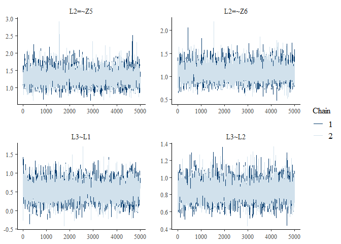

```r
plot(Bfit, c(3:4, 10:11))
```